# Model Output plots

26 November, 2024

Here is a snapshot 📸 of your model outputs for run ID 20241126_005450, from config config_sample_2pop_vaccine_scenarios.yml, stored in model_output.

# 1 Infection timeseries: `SEIR` model output

These are the outputs for the compartmental epidemic model, stored in the `seir` directory, which track the prevalence and incidence of individuals in each model compartment over time.

Incidence values are per day.

```
## [1] "Assuming non-inference run. Ignoring values of global_opt and final_opt if specified"
## [1] "Importing seir files (n = 10):"
```

## 1.1 All infections

Total number of individuals in each infection state over time (compartments defined by `infection_stage`), aggregated across other strata. Plotted for slot 1 which has the highest total likelihood over all subpopulations (if inferrence was run) or was randomly chosen (if no inference).

### 1.1.1 Total

#### 1.1.1.1 Prevalence

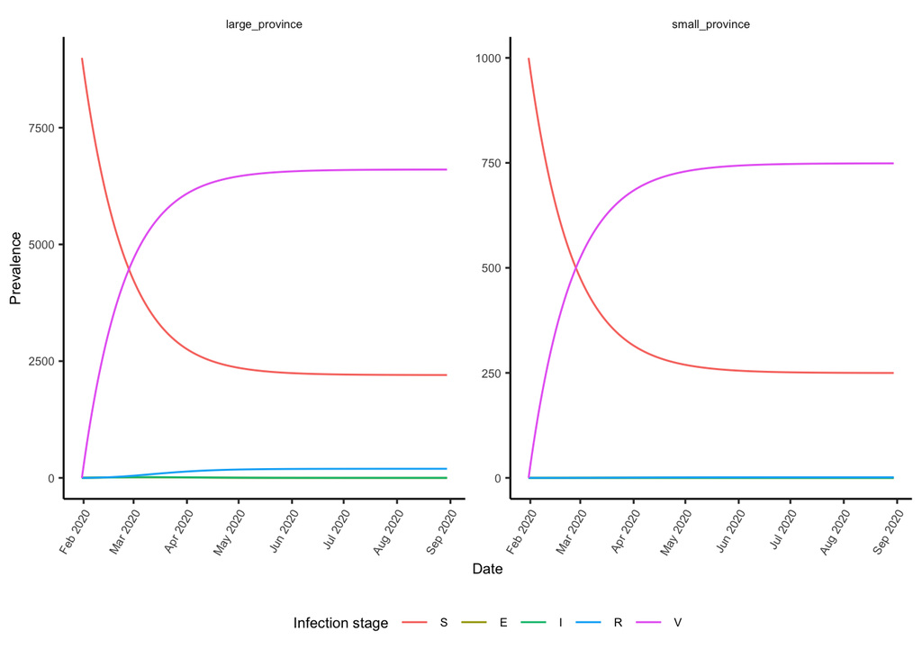

#### 1.1.1.2 Cumulative incidence

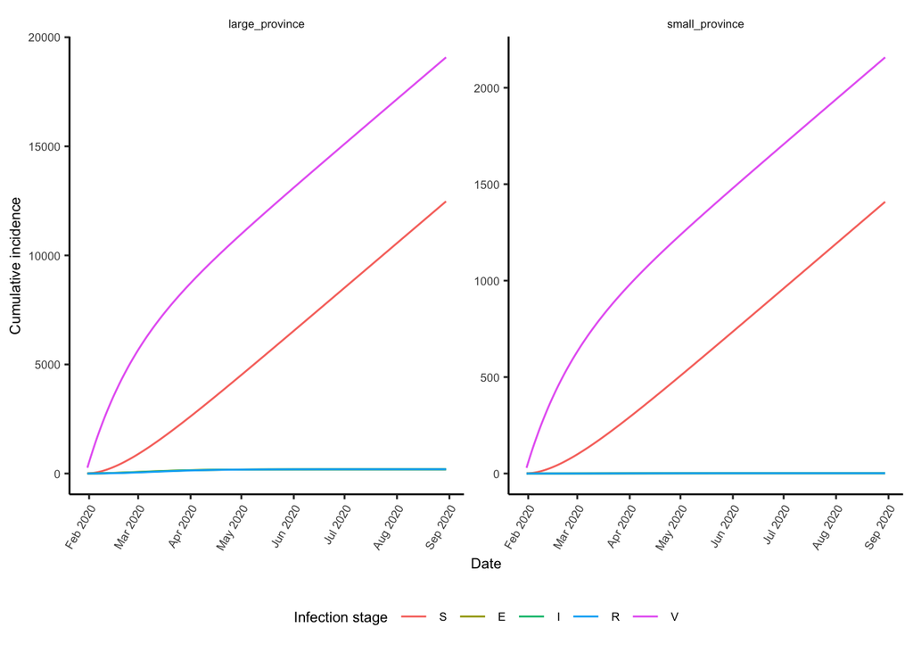

### 1.1.2 Per capita

#### 1.1.2.1 Prevalence

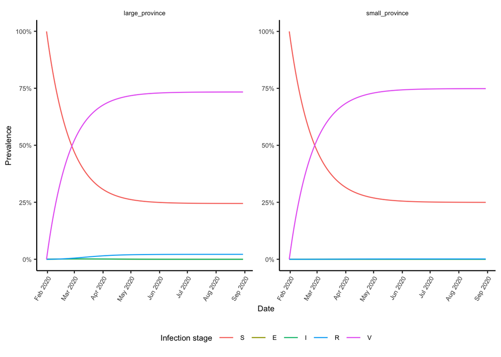

#### 1.1.2.2 Cumulative incidence

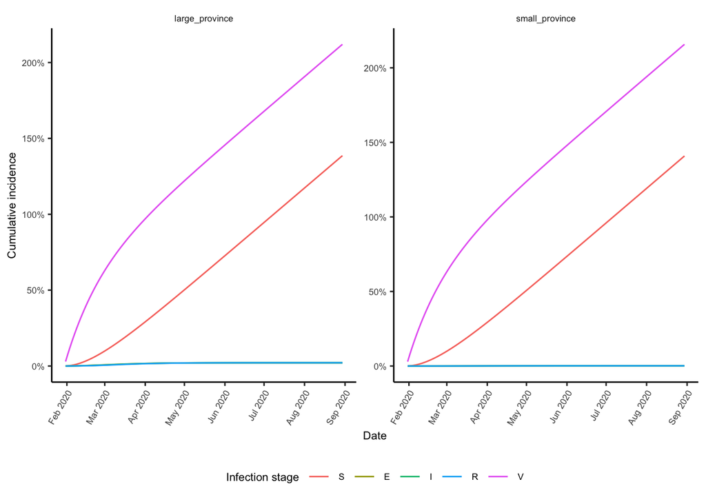

# 2 Outcome timeseries: `HOSP` model output

These are the outputs for the observational (“outcomes”) model, stored in the `hosp` directory, which tracks the incidence and prevalence of individuals with defined observed disease outcomes over time.

## 2.1 Aggregate outcomes

Total number of individuals with each outcome over time, aggregated across other strata (only outcomes without an “_” specifying a stratification are plotted). If more than one simulation (slot) was run, results are plotted for slot 1 which has the highest total likelihood over all subpopulations (if inference was run) or was randomly chosen (if no inference). Incidence values are per day.

If inference was run, only some of these outcomes may have been used in inference, and the outcomes may have been aggregated to a longer time period (e.g., weeks, months). Inference-specific outcomes, along with the data they were compared to, are shown in later plots.

[1] “Assuming non-inference run. Ignoring values of global_opt and final_opt if specified” [1] “Importing hosp files (n = 10):”

### 2.1.1 incidCase

#### 2.1.1.1 Total

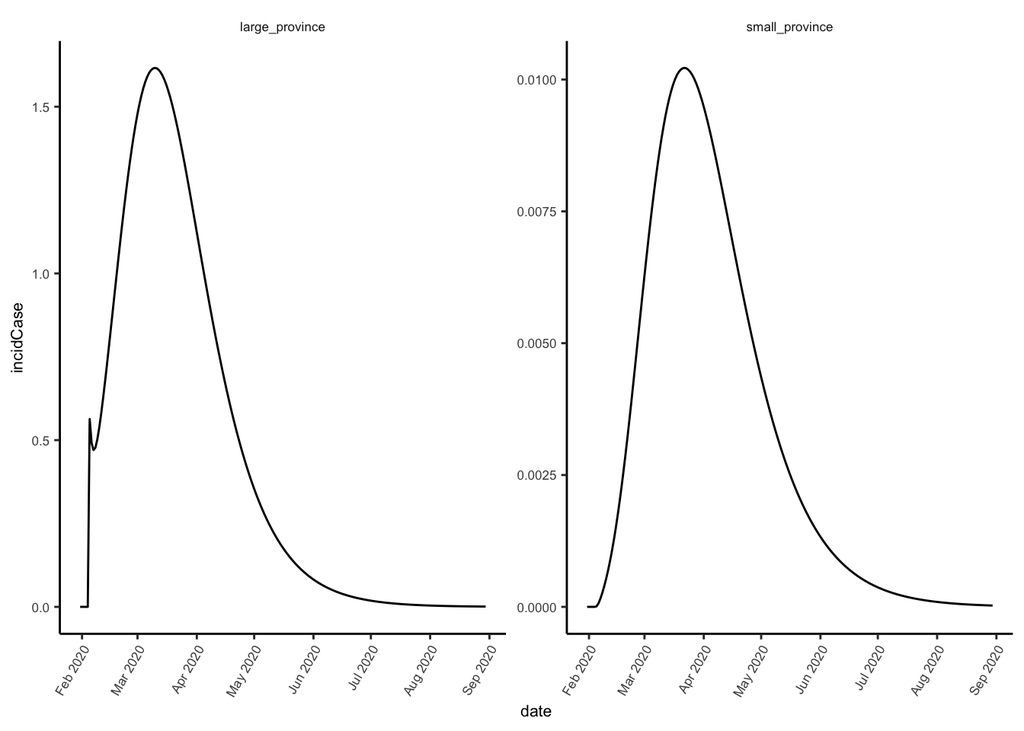

### 2.1.2 incidHosp

#### 2.1.2.1 Total

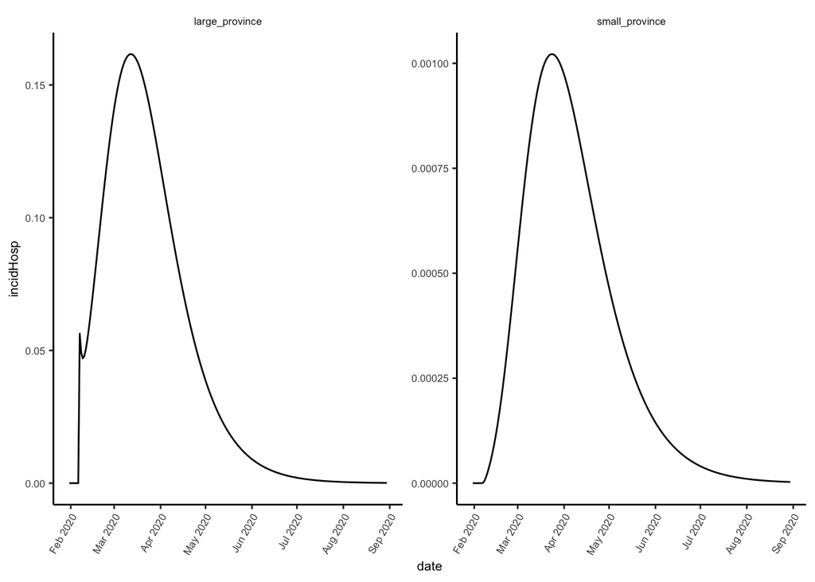